# Lab6

true

2023-03-01

## Case Study: Eel Distribution Modeling

This week’s lab follows a project modeling the eel species Anguilla australis described by Elith et al. (2008). There are two data sets for this lab. You’ll use one for training and evaluating your model, and you’ll use your model to make predictions predictions on the other. Then you’ll compare your model’s performance to the model used by Elith et al.

```r
library(tidyverse)
library(tidymodels)
library(ranger)
library(spData)
library(ggpmisc)
library(vip)
library(xgboost)
```

## Data

Grab the training data sets (eel.model.data.csv, eel.eval.data.csv) from github here: https://github.com/MaRo406/eds-232-machine-learning/blob/main/data

```r
eel_dat <- read_csv("eel.model.data.csv") %>%
  mutate(Angaus = as.factor(Angaus))
eval <- read_csv("eel.eval.data.csv") %>%
  mutate(Angaus_obs = as.factor(Angaus_obs))
```

### Split and Resample

Split the model data (eel.model.data.csv) into a training and test set, stratified by outcome score (Angaus). Use 10-fold CV to resample the training set.

```r
set.seed(456)
#Split the model Data
eel_split <- initial_split(eel_dat)
eel_train <- training(eel_split)
eel_test <- testing(eel_split)

#Create the 10 fold cross validation
folds <- vfold_cv(eel_train, v = 10)
```

### Preprocess

Create a recipe to prepare your data for the XGBoost model

```r
eel_recipe = recipe(Angaus ~ ., data = eel_train) %>% #create model recipe
  step_dummy(all_nominal_predictors()) %>% #create dummy variables from all factors
  step_normalize(all_numeric_predictors()) #normalize all numeric predictors
```

## Tuning XGBoost

### Tune Learning Rate

Following the XGBoost tuning strategy outlined in lecture, first we conduct tuning on just the learning rate parameter:

1. Create a model specification using {xgboost} for the estimation
   - Only specify one parameter to tune()

```r
xgb_model = boost_tree(learn_rate = tune()) %>%
  set_engine("xgboost") %>%
  set_mode("classification")

xgb_workflow = workflow() %>% #create workflow
  add_model(xgb_model) %>% #add boosted trees model
  add_recipe(eel_recipe) #add recipe

xgb_workflow
```

```
## ══ Workflow ════════════════════════════════════════════════════════════════════
## Preprocessor: Recipe
## Model: boost_tree()
##
## ── Preprocessor ────────────────────────────────────────────────────────────────
## 2 Recipe Steps
##
## • step_dummy()
## • step_normalize()
##
## ── Model ───────────────────────────────────────────────────────────────────────
## Boosted Tree Model Specification (classification)
##
## Main Arguments:
##   learn_rate = tune()
##
## Computational engine: xgboost
```

1. Set up a grid to tune your model by using a range of learning rate parameter values: expand.grid(learn_rate = seq(0.0001, 0.3, length.out = 30))
- Use appropriate metrics argument(s) - Computational efficiency becomes a factor as models get more complex and data get larger. Record the time it takes to run. Do this for each tuning phase you run. You could use {tictoc} or Sys.time().

```r
expanded_grid <- expand.grid(learn_rate = seq(0.0001, 0.3, length.out = 30))

system.time({
xgb_cv_tune = xgb_workflow %>%
  tune_grid(resamples = folds, grid = expanded_grid) #use cross validation to tune learn_rate and trees parameter
})
```

```
##    user  system elapsed
##   9.266   0.031   9.343
```

3. Show the performance of the best models and the estimates for the learning rate parameter values associated with each.

```r
collect_metrics(xgb_cv_tune) #get metrics from tuning cv to pick best model
```

```
## # A tibble: 60 × 7
##    learn_rate .metric  .estimator  mean     n std_err .config
##         <dbl> <chr>    <chr>      <dbl> <int>   <dbl> <chr>
##  1     0.0001 accuracy binary     0.819    10 0.0118  Preprocessor1_Model01
##  2     0.0001 roc_auc  binary     0.819    10 0.0198  Preprocessor1_Model01
##  3     0.0104 accuracy binary     0.832    10 0.0102  Preprocessor1_Model02
##  4     0.0104 roc_auc  binary     0.829    10 0.0174  Preprocessor1_Model02
##  5     0.0208 accuracy binary     0.837    10 0.0105  Preprocessor1_Model03
##  6     0.0208 roc_auc  binary     0.838    10 0.0155  Preprocessor1_Model03
##  7     0.0311 accuracy binary     0.843    10 0.00884 Preprocessor1_Model04
##  8     0.0311 roc_auc  binary     0.844    10 0.0152  Preprocessor1_Model04
##  9     0.0415 accuracy binary     0.845    10 0.0116  Preprocessor1_Model05
## 10     0.0415 roc_auc  binary     0.847    10 0.0141  Preprocessor1_Model05
## # ℹ 50 more rows
```

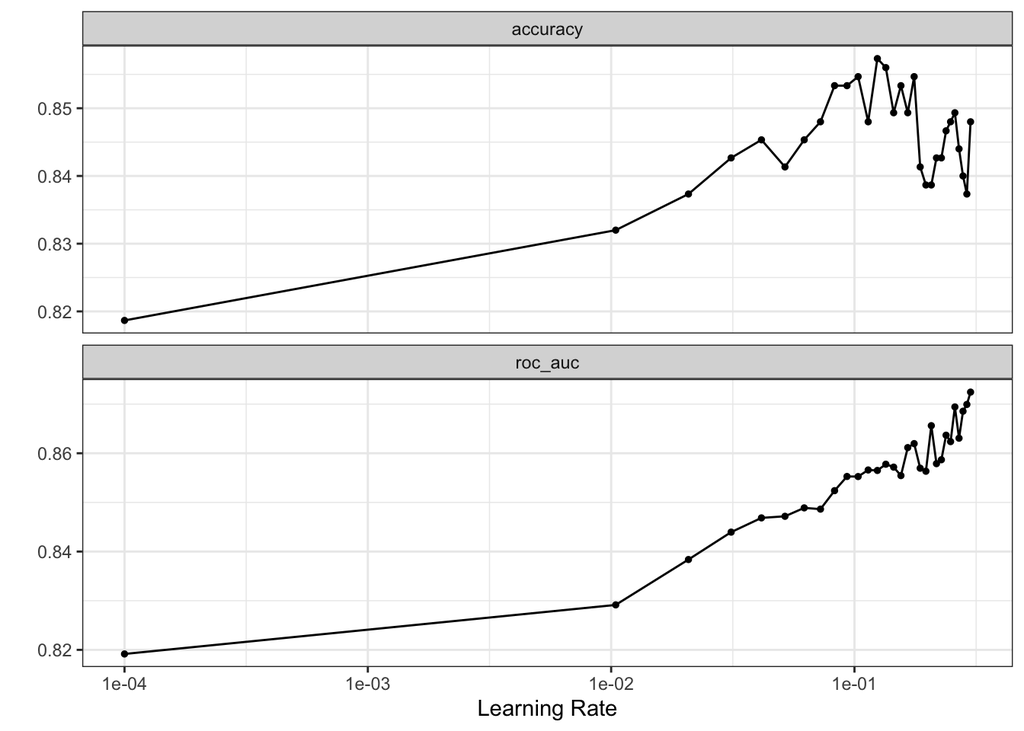

```r
autoplot(xgb_cv_tune) + #plot cv results for parameter tuning
  theme_bw()
```

```r
xgb_best = show_best(xgb_cv_tune, n = 1, metric = "accuracy") #get metrics for best random forest model
xgb_best
```

```
## # A tibble: 1 × 7
##   learn_rate .metric  .estimator  mean     n std_err .config
##        <dbl> <chr>    <chr>      <dbl> <int>   <dbl> <chr>
## 1      0.124 accuracy binary     0.857    10 0.00821 Preprocessor1_Model13
```

### Tune Tree Parameters

1. Create a new specification where you set the learning rate (which you already optimized) and tune the tree parameters.

```r
xgb_model2 = boost_tree(learn_rate = 0.1241966,
                        trees = 3000,
                        tree_depth = tune(),
                        min_n = tune(),
                        loss_reduction = tune()) %>%
  set_engine("xgboost") %>%
  set_mode("classification")
xgb_workflow2 = workflow() %>% #create workflow
  add_model(xgb_model2) %>% #add boosted trees model
  add_recipe(eel_recipe) #add recipe
```

1. Set up a tuning grid. This time use grid_latin_hypercube() to get a representative sampling of the parameter space

NOTE : if no grid is specified, tune_grid will use grid_latin_hypercube()

```r
xgb2_cv_tune = xgb_workflow2 %>%
  tune_grid(resamples = folds)
```

1. Show the performance of the best models and the estimates for the tree parameter values associated with each.

```r
xgb_best2 = show_best(xgb2_cv_tune, n = 1, metric = "accuracy") #get metrics for best random forest model
xgb_best2
```

```
## # A tibble: 1 × 9
##   min_n tree_depth loss_reduction .metric .estimator  mean     n std_err .config
##   <int>      <int>          <dbl> <chr>   <chr>      <dbl> <int>   <dbl> <chr>
## 1     4          8    0.000000322 accura… binary     0.819    10 0.00957 Prepro…
```

### Tune Stochastic Parameters

1. Create a new specification where you set the learning rate and tree parameters (which you already optimized) and tune the stochastic parameters.

   xgb_workflow3 = workflow() %>% #create workflow
     add_model(xgb_model3) %>% #add boosted trees model
     add_recipe(eel_recipe) #add recipe

   xgb <- xgb_model3 %>%
     extract_parameter_set_dials()
   ```

2. Set up a tuning grid. Use grid_latin_hypercube() again.

```r
tune <- xgb_workflow3 %>%
  tune_grid(resamples = folds,
            grid = grid_latin_hypercube(finalize(xgb, x = eel_train)),
                                        size = 10)
show_best(tune, n = 1, metric = "accuracy")
```

```
## # A tibble: 1 × 8
##    mtry sample_size .metric  .estimator  mean     n std_err .config
##   <int>       <dbl> <chr>    <chr>      <dbl> <int>   <dbl> <chr>
## 1     5       0.740 accuracy binary     0.824    10  0.0103 Preprocessor1_Model3
```

1. Show the performance of the best models and the estimates for the tree parameter values associated with each.

## Finalize workflow and make final prediction

1. How well did your model perform? What types of errors did it make?

## Fit your model the evaluation data and compare performance

1. Now used your final model to predict on the other dataset (eval.data.csv)

```r
eel_recipe2 = recipe(Angaus_obs ~ ., data = eval) %>% #create model recipe
  step_dummy(all_nominal_predictors()) %>% #create dummy variables from all factors
  step_normalize(all_numeric_predictors()) #normalize all numeric predictors
```

```r
xgb_workflow4 = workflow() %>% #create workflow
  add_model(xgb_model3) %>% #add boosted trees model
  add_recipe(eel_recipe2) #add recipe


#final_fit <- xgb_workflow3 %>% fit(data = eval)
```